# Red Wine Exploratory Data Analysis

Shrey Marwaha

September 20, 2017

## Objectives

Through this project, I aim to explore and analyse the Red Wine Data Set, and infer the factors on which the quality of wine depends. I will start by exploring the data to get a feel of the information available and then, if possible, I hope to draw out the correlations between the various variables and Wine Quality.

I have created a new variable **class** here, which is based on quality ratings. It has been divided as follows:

- *poor* : Quality rating 3 and 4
- *normal* : Quality rating 5 and 6
- *exceptional* : Quality rating 7 and 8

## Structure and summary of the Dataframe

```
## 'data.frame':    1599 obs. of  14 variables:
##  $ X                   : int  1 2 3 4 5 6 7 8 9 10 ...
##  $ fixed.acidity       : num  7.4 7.8 7.8 11.2 7.4 7.4 7.9 7.3 7.8 7.5 ...
##  $ volatile.acidity    : num  0.7 0.88 0.76 0.28 0.7 0.66 0.6 0.65 0.58 0.5 ...
##  $ citric.acid         : num  0 0 0.04 0.56 0 0 0.06 0 0.02 0.36 ...
##  $ residual.sugar      : num  1.9 2.6 2.3 1.9 1.9 1.8 1.6 1.2 2 6.1 ...
##  $ chlorides           : num  0.076 0.098 0.092 0.075 0.076 0.075 0.069 0.065 0.073 0.071 ...
##  $ free.sulfur.dioxide : num  11 25 15 17 11 13 15 15 9 17 ...
##  $ total.sulfur.dioxide: num  34 67 54 60 34 40 59 21 18 102 ...
##  $ density             : num  0.998 0.997 0.997 0.998 0.998 ...
##  $ pH                  : num  3.51 3.2 3.26 3.16 3.51 3.51 3.3 3.39 3.36 3.35 ...
##  $ sulphates           : num  0.56 0.68 0.65 0.58 0.56 0.56 0.46 0.47 0.57 0.8 ...
##  $ alcohol             : num  9.4 9.8 9.8 9.8 9.4 9.4 9.4 10 9.5 10.5 ...
##  $ quality             : Ord.factor w/ 6 levels "3"<"4"<"5"<"6"<..: 3 3 3 4 3 3 3 5 5 3 ...
##  $ class               : Ord.factor w/ 3 levels "poor"<"normal"<..: 2 2 2 2 2 2 2 3 3 2 ...
```

```
##        X          fixed.acidity   volatile.acidity  citric.acid
##  Min.   :   1.0   Min.   : 4.60   Min.   :0.1200   Min.   :0.000
##  1st Qu.: 400.5   1st Qu.: 7.10   1st Qu.:0.3900   1st Qu.:0.090
##  Median : 800.0   Median : 7.90   Median :0.5200   Median :0.260
##  Mean   : 800.0   Mean   : 8.32   Mean   :0.5278   Mean   :0.271
##  3rd Qu.:1199.5   3rd Qu.: 9.20   3rd Qu.:0.6400   3rd Qu.:0.420
##  Max.   :1599.0   Max.   :15.90   Max.   :1.5800   Max.   :1.000
##  residual.sugar     chlorides       free.sulfur.dioxide
##  Min.   : 0.900   Min.   :0.01200   Min.   : 1.00
##  1st Qu.: 1.900   1st Qu.:0.07000   1st Qu.: 7.00
##  Median : 2.200   Median :0.07900   Median :14.00
##  Mean   : 2.539   Mean   :0.08747   Mean   :15.87
##  3rd Qu.: 2.600   3rd Qu.:0.09000   3rd Qu.:21.00
##  Max.   :15.500   Max.   :0.61100   Max.   :72.00
##  total.sulfur.dioxide    density             pH          sulphates
##  Min.   :  6.00       Min.   :0.9901   Min.   :2.740   Min.   :0.3300
##  1st Qu.: 22.00       1st Qu.:0.9956   1st Qu.:3.210   1st Qu.:0.5500
##  Median : 38.00       Median :0.9968   Median :3.310   Median :0.6200
##  Mean   : 46.47       Mean   :0.9967   Mean   :3.311   Mean   :0.6581
##  3rd Qu.: 62.00       3rd Qu.:0.9978   3rd Qu.:3.400   3rd Qu.:0.7300
##  Max.   :289.00       Max.   :1.0037   Max.   :4.010   Max.   :2.0000
##     alcohol      quality         class
##  Min.   : 8.40   3: 10   poor       :  63
##  1st Qu.: 9.50   4: 53   normal     :1319
##  Median :10.20   5:681   exceptional: 217
##  Mean   :10.42   6:638
##  3rd Qu.:11.10   7:199
##  Max.   :14.90   8: 18
```

# Univariate Plots Section

As a start, I see from the above statistics that there are a lot more number of **normal** red wines in the data, than ‘poor’ and ‘exceptional’. Let’s have a visual look at this by checking quality factor.

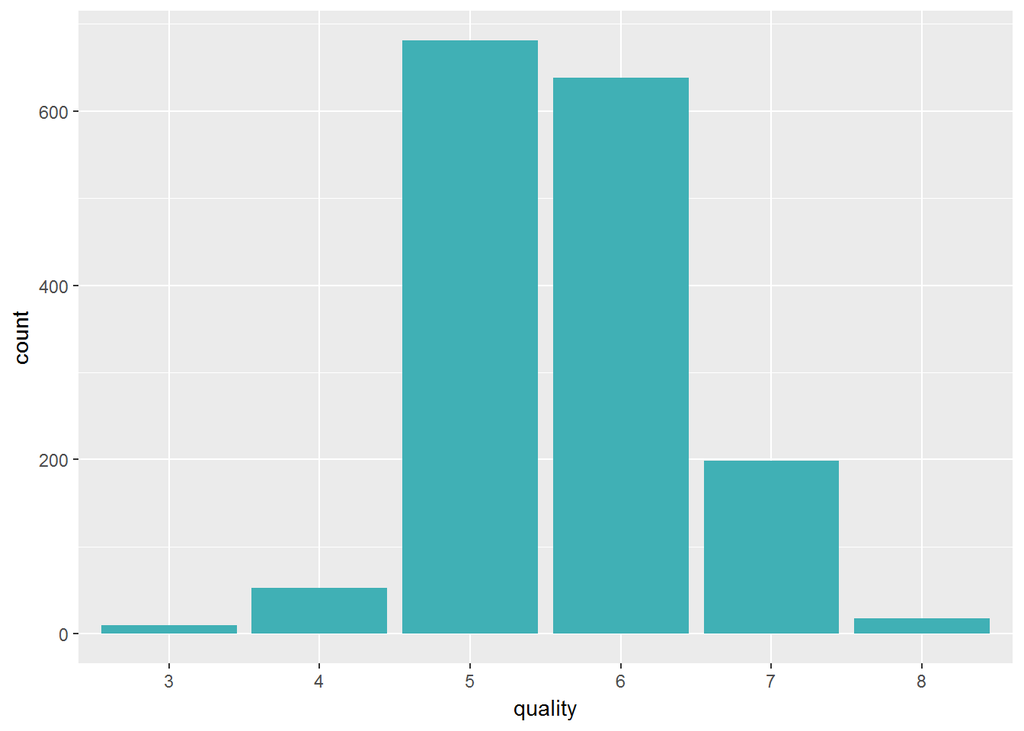

That shows it quite clearly, as is mentioned in the Info file. I wonder if wines with quality rating 8 (exceptional) and quality rating 3 (poor) are outliers.

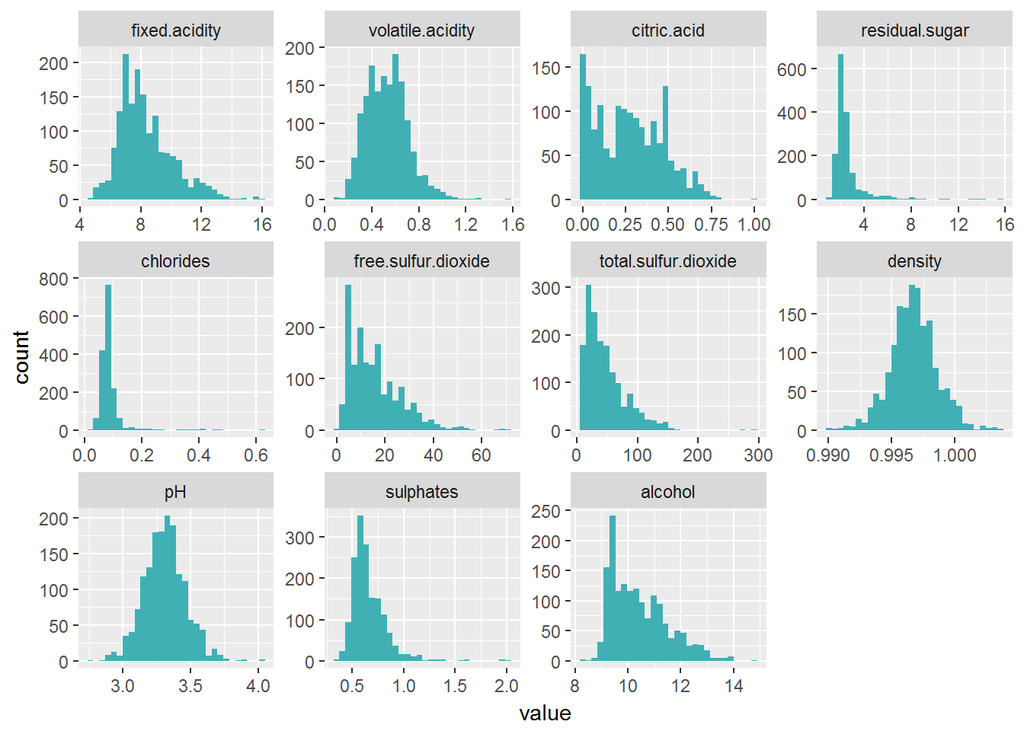

From the above initial plots, a lot of interesting things can be seen. Many variables are showing some kind of a relationship which can be of particular interest to us. Let’s examine some of these further. I’ll go about doing this category wise, namely: Acidity, Chemicals and Other features.

### Acidity

From the data, we can see that pH, fixed.acidity, volatile.acidity and citric.acid basically correspond to this category. Let’s have a look at their distributions, together.

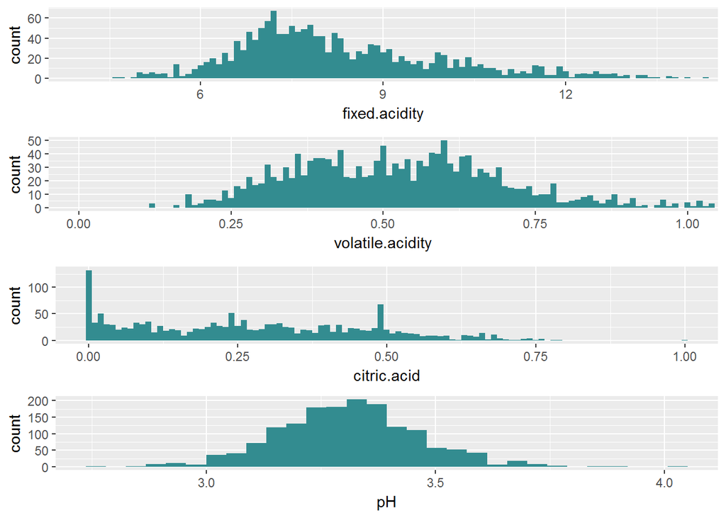

I would like to see some x-axis transformations in citric.acid plot to extract any available information.

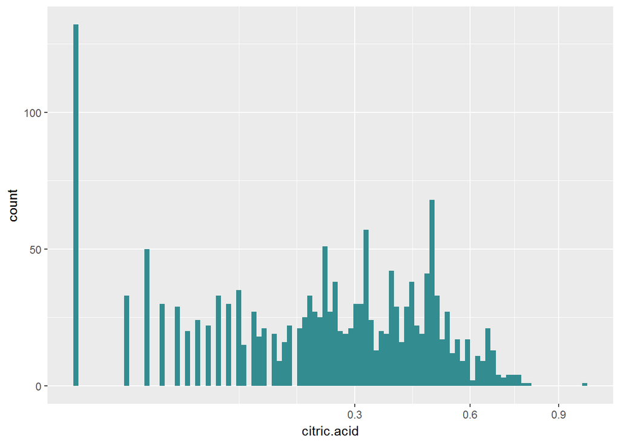

After a sqrt tranformation on x-axis, I can see that although there isn’t relation visible, but many of the values have zero amount of citric acid in them. This probably depends on the flavor of the wine, and probably affects the quality.

### Chemicals

Let’s check for presence of chemicals such as chlorides, sulphates & sulfur dioxide.

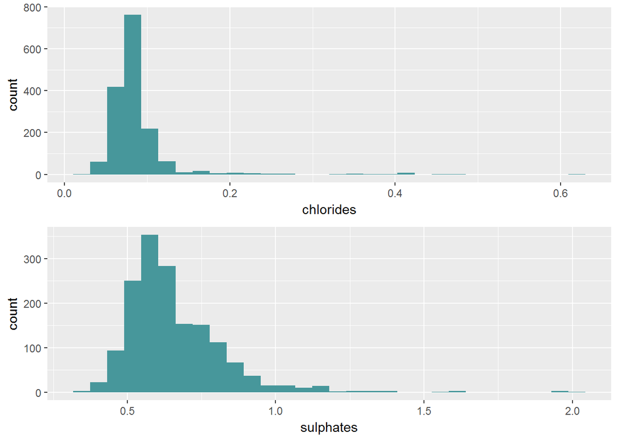

Both these curves show skewed distribution, and a large number of outliers. It’s possible that these abnormal values may distinguish the quality/class of the wine, as presence of long tailed data is visible.

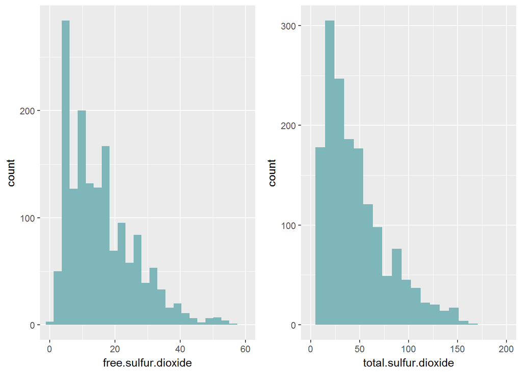

### Other Parameters

Let’s look at residual sugar, density and alcohol levels.

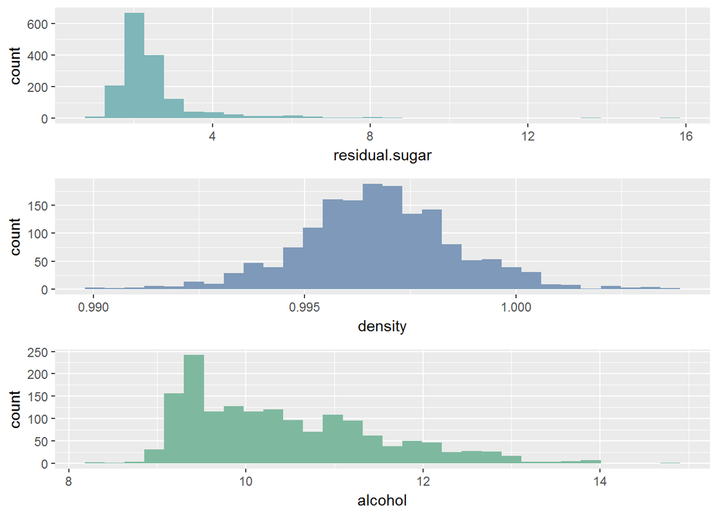

# Univariate Analysis

### Structure of the Dataset

The Red Wine Dataset has 1599 rows and 13 columns. I’ve added a new column called ‘class’ based on the quality ratings. This is to help in distinguishing various trends between chemical properties across classes, as sometimes sensory perception of two people may not exactly mean the same thing. So this type of grouping helps to approximate the trends across adjacent ratings.

Also, both class and Quality have been transformed into factor variables for easy analysis. Final number of variables is 14.

### Feature(s) of Interest

Most data points belong to the **normal** class of wines. This is either a good indication, or implies that data is incomplete. Analysis of multiple variables with quality may clear this up further.

### Supporting Points of Interest

From the intial analysis it seems that variables such as factors related to acidity and pH may be some deciding factors for quality, since the taste is affected by these. By the same clause, chlorides and residual sugars may also affect the perception of quality.

### Unusual Observations

1. The plot of citric.acid qauntity seemed to have no particular relationship going on. A large number of values were seemingly zero, which is either an indication of quality, or incomplete data. To better visualize it, I used the square root transformation, because log transformation would have lead to non-finite values.
2. Other variables such as chlorides, sulphates and residual sugar have many outliers. It intrigues me if these actually propose a measure of quality or are just dirty values.

# Bivariate Plots Section

Although I have some bivariate analyses in mind, I will start by creating a correlation plot to double check my thoughts.

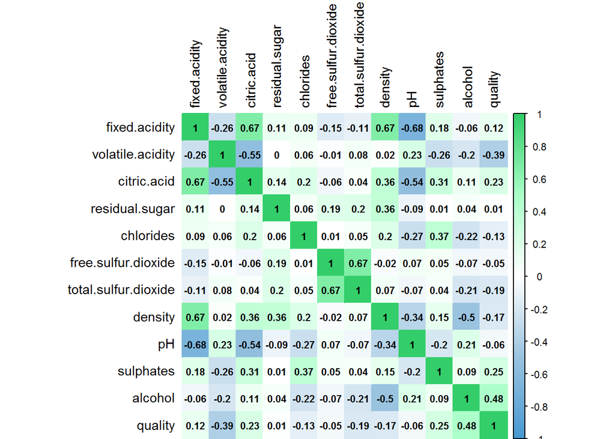

From the above map, the following are some of the facts that intrigue me:

1. Quality is **highly correlated** with **Alcohol and Volatile Acidity**, although in opposite manners.
2. Fixed acidity seems to be **highly correlated** with **citric acid, density** **and pH**.
3. pH seems to be **positively correlated** with **Volatile Acidity**. I assumed it to  
   be the other way round, i.e. similar to fixed acidity.
4. Sulphates and Chlorides seem to be **moderately positively correlated**. This may  
   not lead to an actual relationship though between the two chemicals specifically,  
   but it may be the case that they are present in proportionate amounts in good  
   quality wines.

#### Let’s look at some plots to verify our above hypothesis.

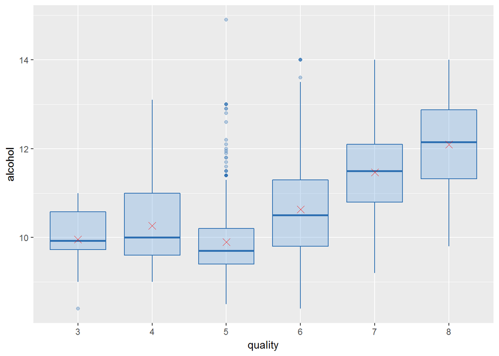

So the alcohol content increases with quality, the exception in this plot being quality rating 5 with a large number of outliers. The mean values as well as the median values clearly express this fact. We can create percentage ranges for Alcohol levels and see the distribution of quality rating in each range as well.

```
## rdw.alcohol.ranges
##   (8,9]  (9,10] (10,11] (11,13] (13,15]
##      37     710     444     385      23
```

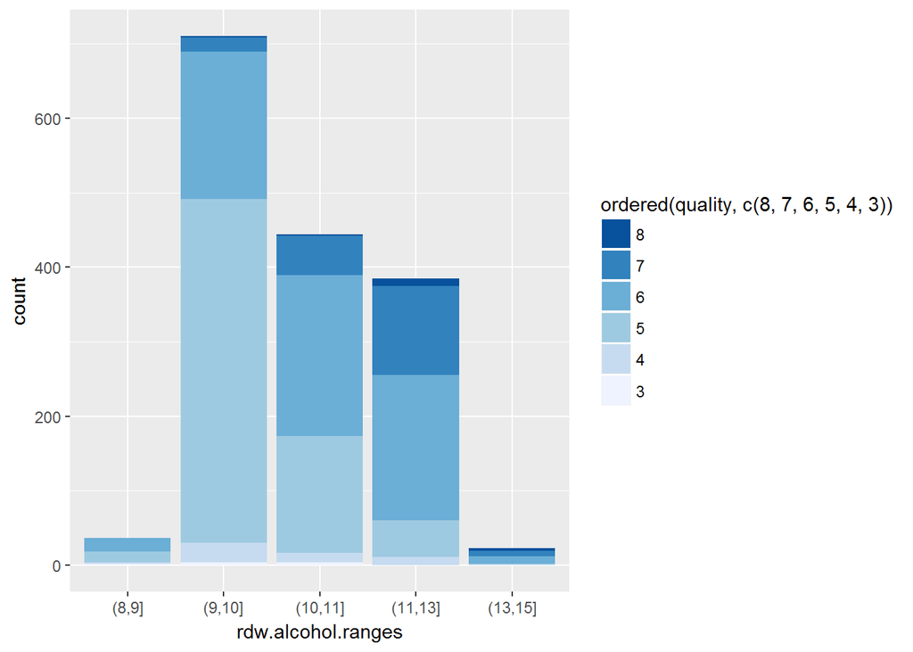

This graph shows that though the majority of **normal**(5 & 6) quality red wines are present in the 9-11% alcohol content range, the **exceptional** ones (7 & 8) tend to be on the higher side in alcohol levels.

Taking a look at volatile.acidity vs Quality, which is expected to have a high negative correlation.

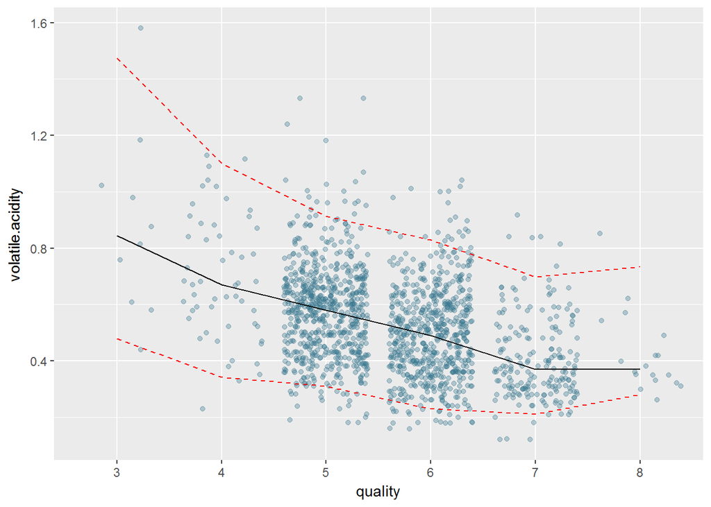

From the median, 97th percentile, and the 3rd percentile, we clearly see a declining relationship with quality. And volatile acidity values for normal quality are packed mostly in the 0.2 to 0.8 range.

Let’s have a look at fixed.acidity and variables correlated with it.

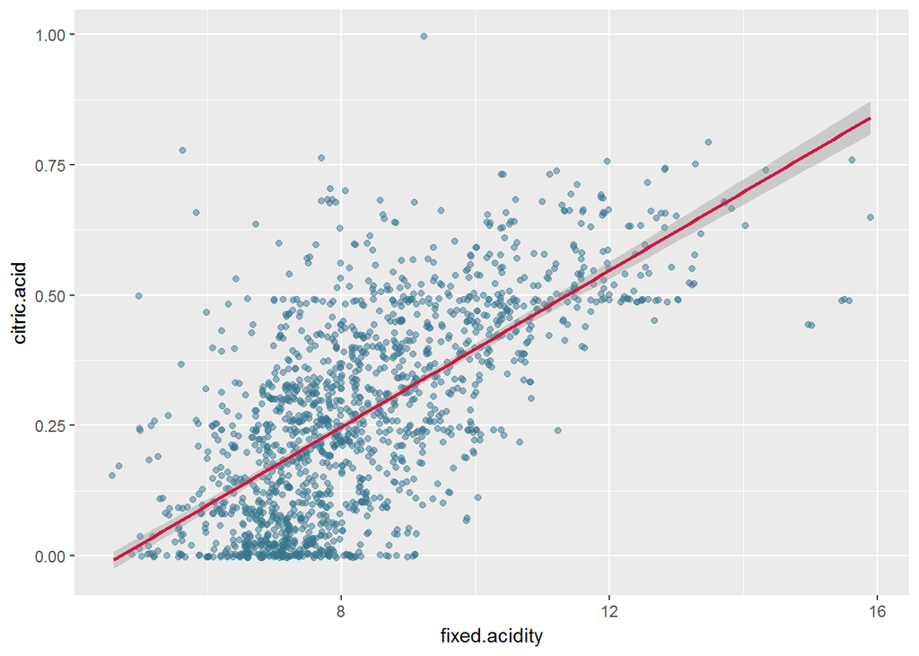

Fixed acidity definitely increases with higher amounts of Citric acid. Probably because citric acid may be the main constituent of acidic nature of the wine. Volatile acidity has a negative relation, so we might need to investigate these together in Multivariate Analyses section.

Let’s check the relationship between fixed.acidity and density.

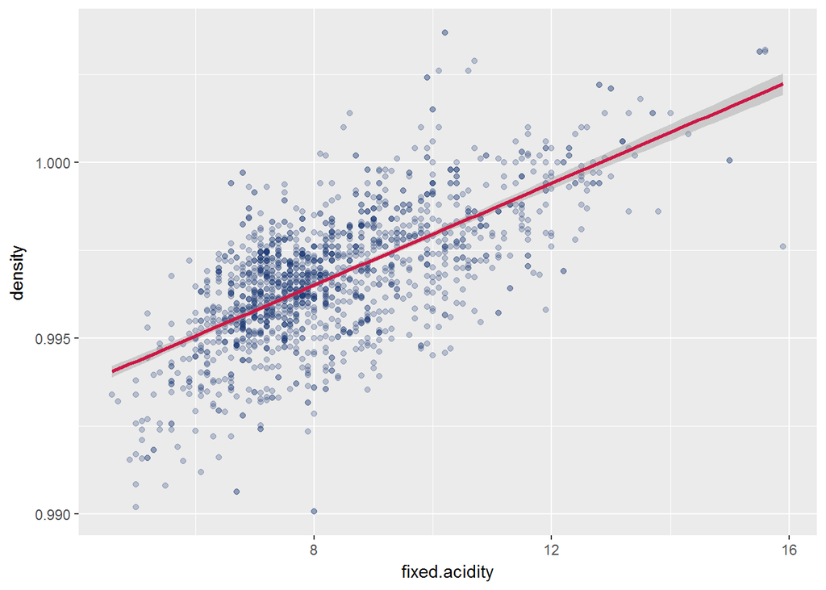

Clearly a positive relationship between these two factors. Let’s see if density affects quality majorly.

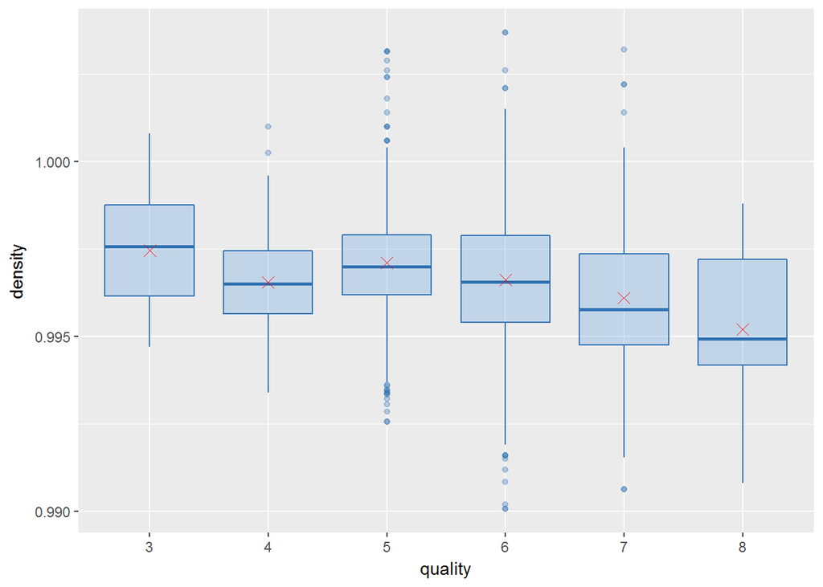

This plot doesn’t really lead to any new conclusions. Density isn’t affective in determining quality.

What about acidity vs pH? Correlation coefficient for fixed.acidity is negative, which is to be expected as higher acidity implies lower pH Value. Let’s check for volatile.acidity and citric.acid. We will keep the x axis in log scale to better view the data.

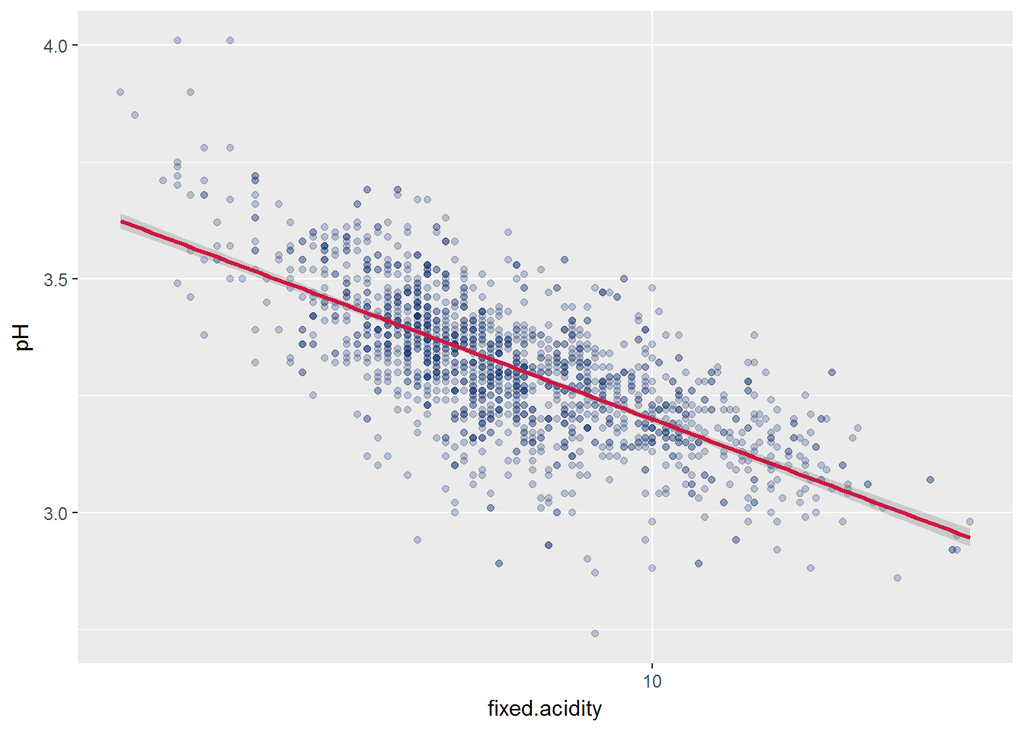

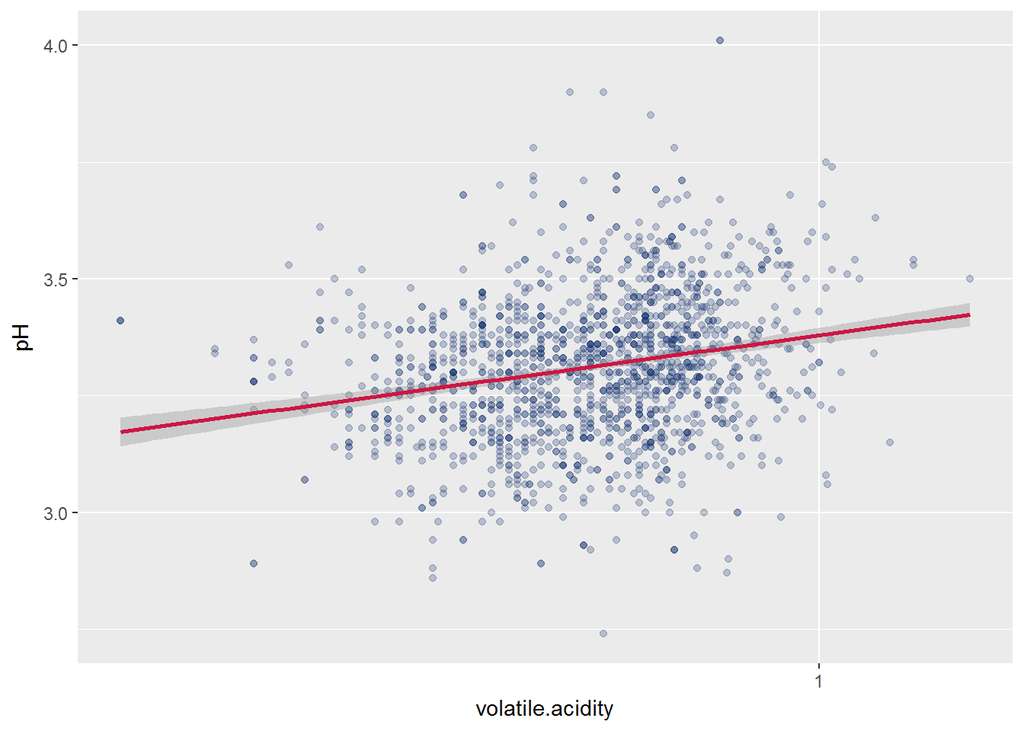

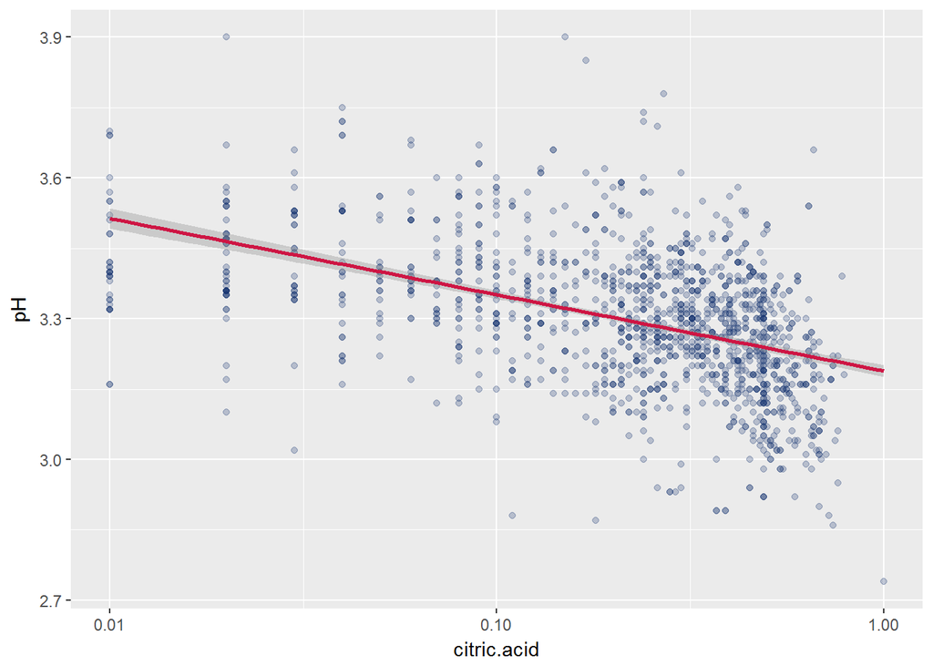

Clearly, volatile acidity has a positive relationship with pH as opposed to fixed.acidity and citric.acid. This finding is crucial, and will be evaluated further in the next section.

Let’s have a look at Sulphates and Chlorides.

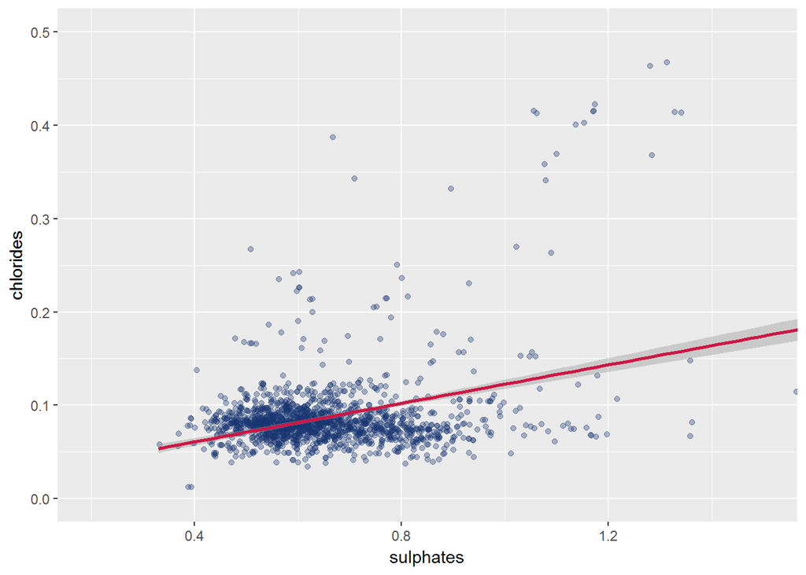

There is a basic linear relationship between the two, but a lot of outliers do exist. Let’s compare them with Quality.

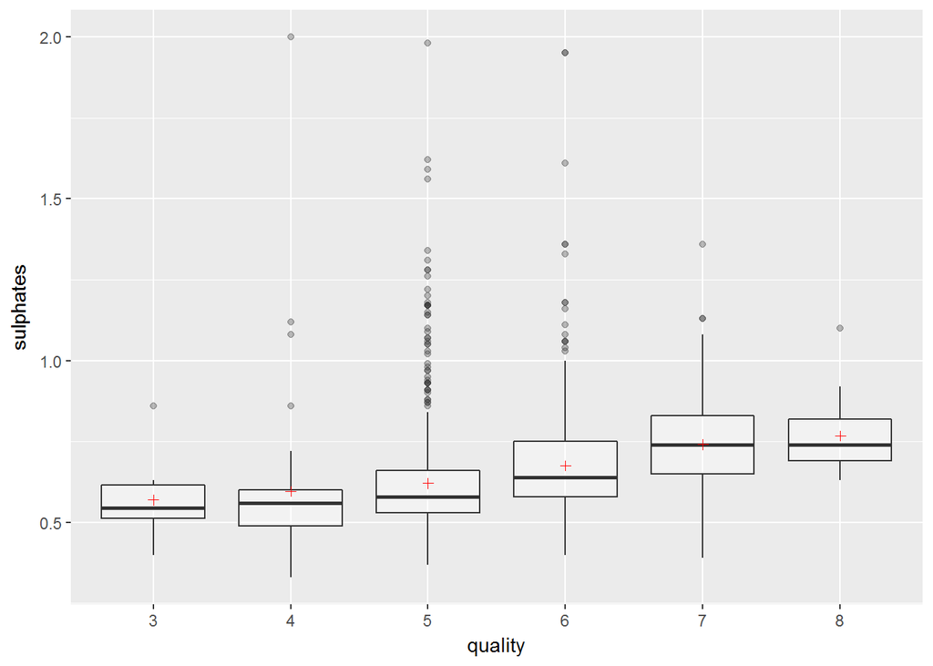

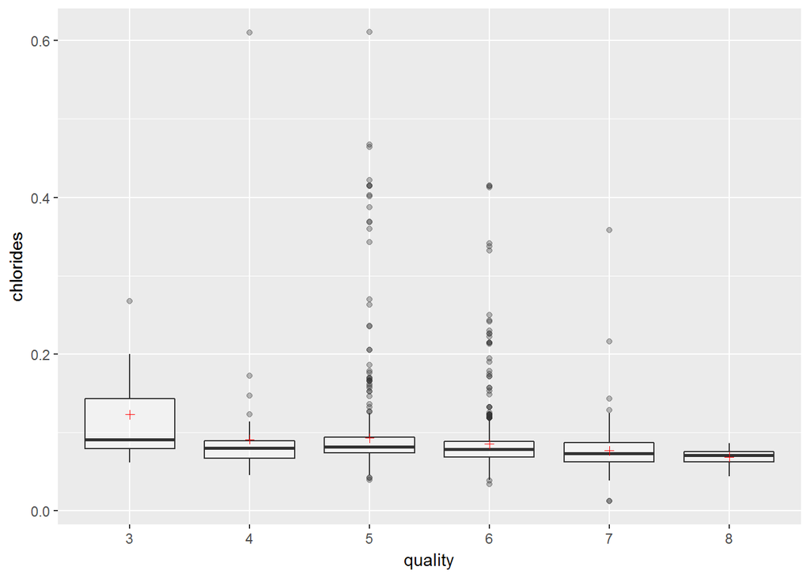

Though for chlorides, the distribution across quality remains more or less constant,  
we can see a large number of outliers for both chlorides and sulphates in the normal (5 & 6) quality wines. Also, for quality rating 3 (lowest), we see a large average quantity of chlorides, while it remains fairly same across higher ratings.

# Bivariate Analysis

### Observations with respect to Feature of Interest

Our main feature of interest is quality. So from our above analysis we can hypothesize the following:

### Other Interesting Features

I expected volatile acidity to add to the total acidity factor through pH. A reverse trend was seen, with higher volatile acidity aiding in increasing the pH.

Also, it amazed me to find a lot of citric acid values to be zero, when its amount was found to be higher in higher quality wines. That might be because of personal prefernces, as it’s mentioned in the information text that no values are missing from the dataset.

### Strongest Relationship

The strongest relationship I found, measured on the basis of correlation coefficient, is between pH and fixed.acidity. The r value is **-0.68**.

# Multivariate Plots Section

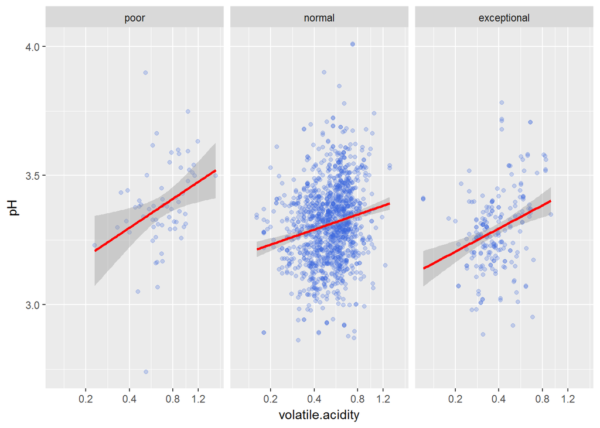

There isn’t much difference to the relation between pH and volatile acidity, across quality. Let’s check it w.r.t. alcohol levels as it seems to be a major factor.

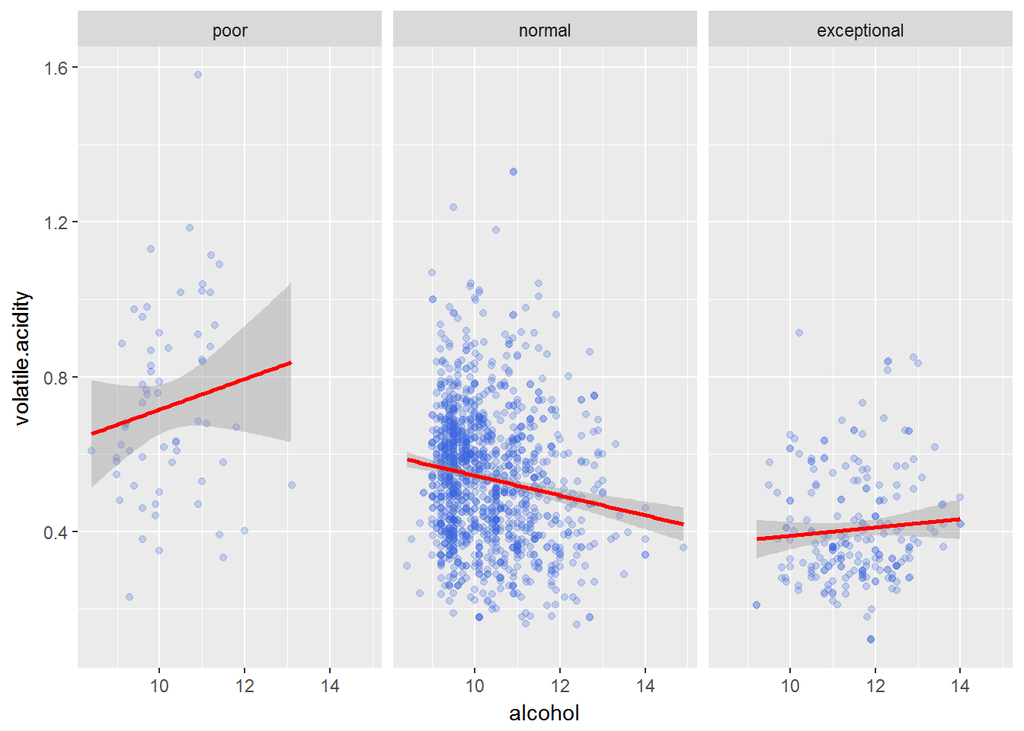

Clearly shows that higher volatile acidity content leads to poor quality. The declining trend in **normal** class, confirms this. I will crosscheck it’s scientific reason, and document it at a later stage.

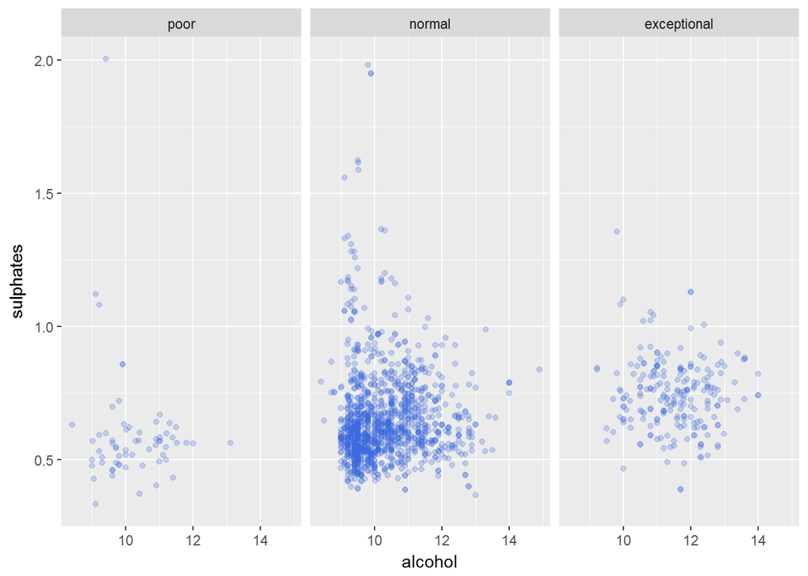

Exceptional quality wines tend to have larger quantities of sulphates and alcohol, relatively. It could be that higher levels of alcohol content coupled with the same amount of sulphates may also be a factor here.

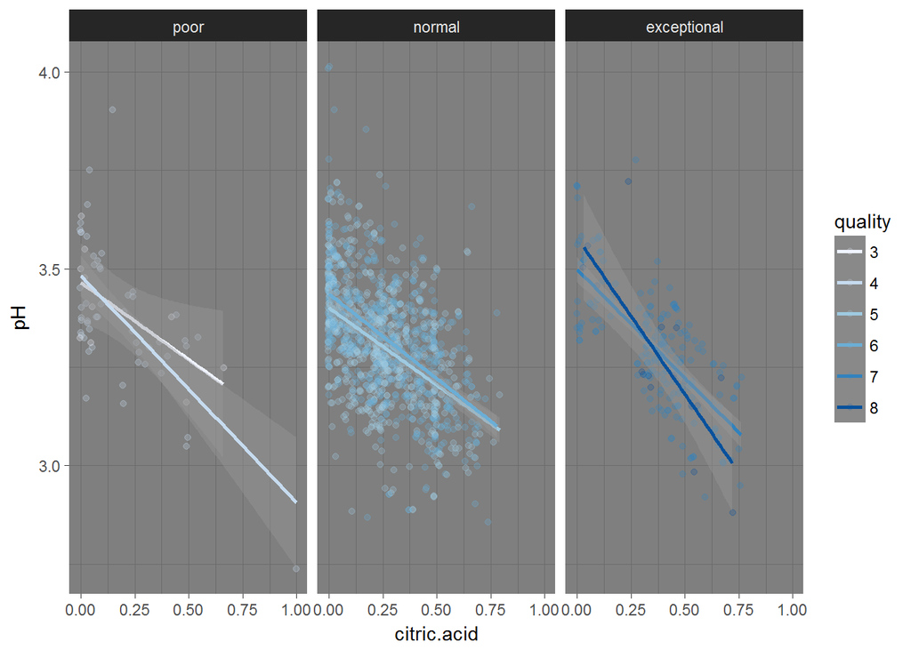

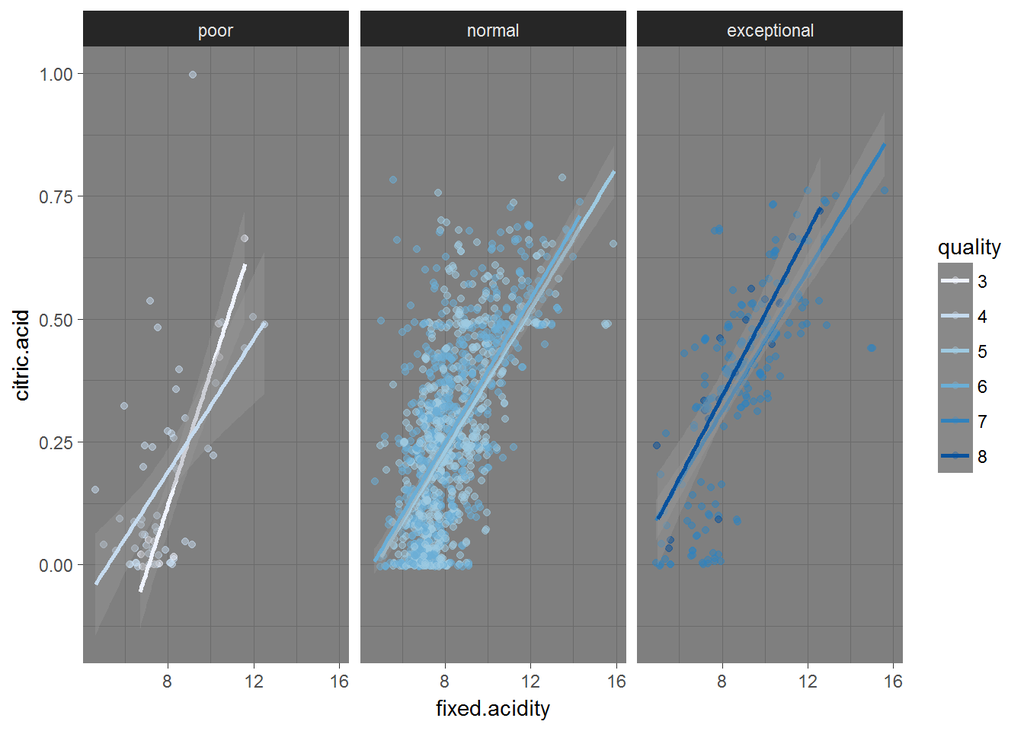

Let’s once check again the correlation coefficients of the above analysed variables with respect to quality only.

```
##                        [,1]
## alcohol           0.4761663
## citric.acid       0.2263725
## volatile.acidity -0.3905578
## sulphates         0.2513971
```

# Multivariate Analysis

### Interesting Observations

The final analysis yieldid a significant relationship between **Quality and** **Alcohol levels, sulphates and volatile acidity**. To a certain extent, **citric acid** also favours quality, by increasing the fixed acidity and hence the pH.

### Other Relevant Observations

*The above mentioned observations cannot be finalised based on the data provided, but I do feel that a larger dataset would’ve made them concrete.*

# Final Plots and Summary

### Plot One

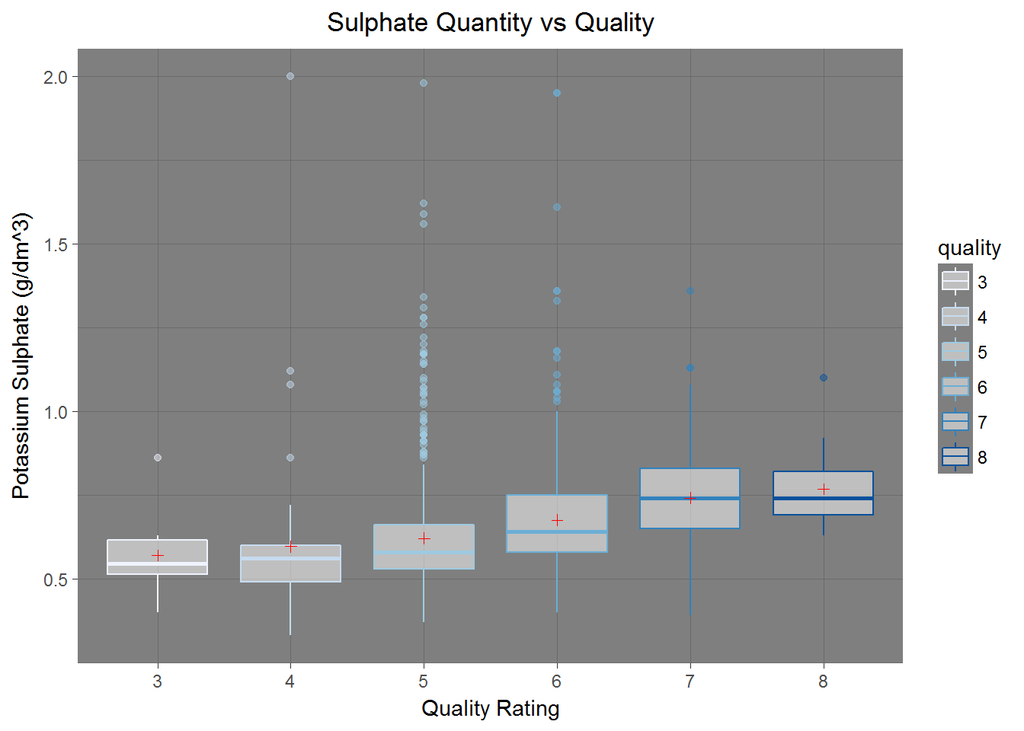

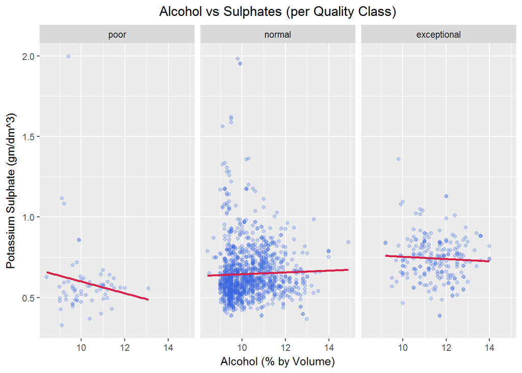

### Description One

These two plots together quite reasonably show the importance of sulphates in Wine Quality. The first boxplot has a clear upward trend in Potassium sulphate amount with across quality. The mean moves mostly along the median line. This established this factor as an important ingredient. The second plot shows how crucial a role does Sulphate amount play across classes, along with the most prominent ingredient, alcohol. It’s clear that for poor quality wines, the sulphate amount drops down, for normal quality wines, it shows an increasing trend with in increase in alcohol levels, but for exceptional classes, it doesn’t really make a significant difference. At higher alcohol levels, a bare threshold amount of sulphate compounds is sufficient.

### Plot Two

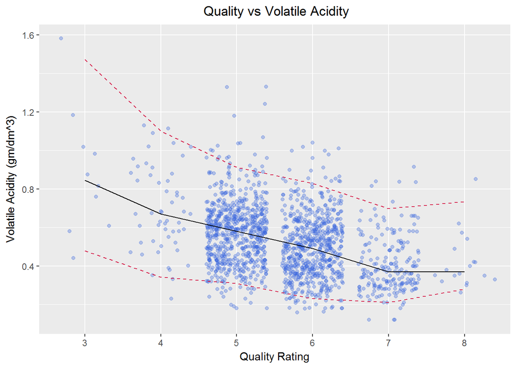

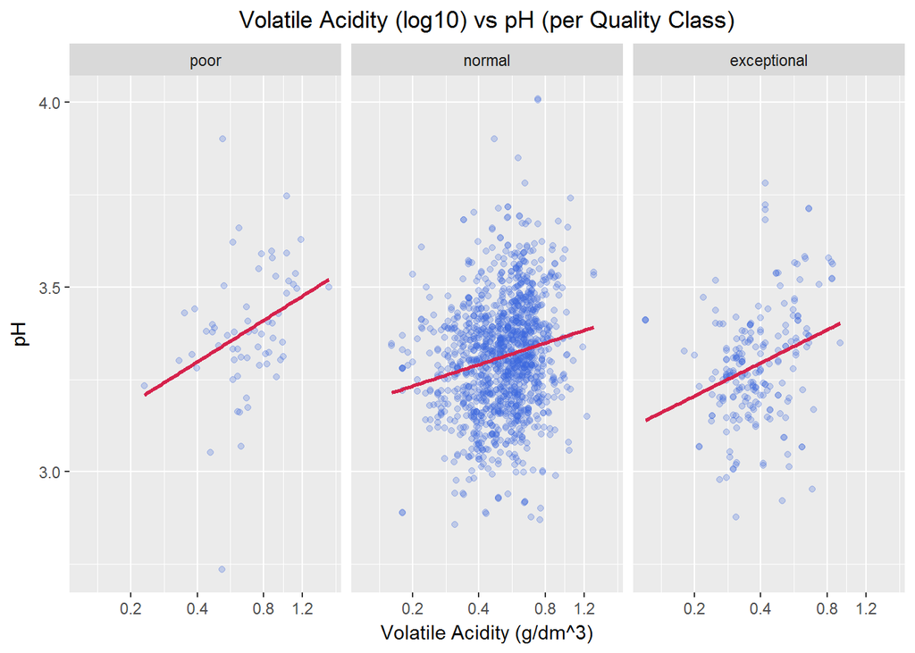

### Description Two

These two plots together serve the purpose of clarifying the mystery behind volatile acidity. After I confirmed this relationship through these charts, I was sure about one thing that Volatile Acidity (VA) is actually not contributing to the acidity of the wine! And after searching the internet, I found out that increased levels of **acetic acid, the source of volatile acidity**, implies overfermentation, which spoils the wine. It’s undesireable! And secondly, a **low pH value inhibits development of microorganisms!** Hence, at higher pH values, we can see higher VA values! So VA becomes a definite factor in deciding quality!

### Plot Three

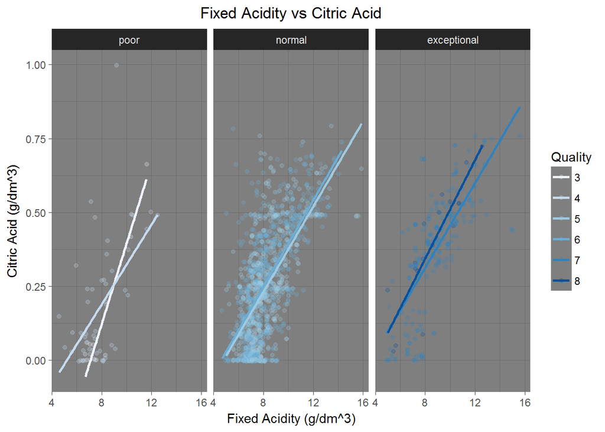

### Description Three

Though not exactly giving a relationship towards quality, this graph quite clearly depicts the linear relationship between fixed acidity and **citric acid**. Fixed acidity is composed of **tartaric acid** in majority, and it seems that citric acid is added in proportion, to enhance the fruitiness of the wine.

# Reflection

Having no previous perceptory or scientific knowledge of Red wines, it was initially difficult for me to get a feel of the provided information. After the initial analysis, it got cleared up to a certain degree. I approached this analysis with the methodology of generating some conclusions through my analysis and then verifying them scientifically. This strategy worked in my favour.

Throughout this analysis, I did feel that the outcomes were being hindered by the amount of data. The dataset contains most values in the normal quality class, which makes it biased to a certain extent. I couldn’t decide if modelling with such a dataset would yield conclusive results or not.

The main noteworthy finding for me was the presence of Volatile Acidity in Red Wines. When I saw the declining trend with Quality in the Univariate section, it intrigued me to see reversal in trends between volatile acidity and fixed acidity. Through further analysis in Bivariate and Multivariate sections, I strengthened this hypothesis. And the scientific reasoning for it confirmed that higher levels of Volatile acidity are not preferred and it’s increase is aided by higher pH values.

I do wish that this dataset was larger in size and without skewed data for a single quality measure, for effective modelling purposes. Although I have never tried wine, I also believe that these quality ratings may be subjective, and dependent on the preferences of the ones grading them. So, for a better analysis, it would be prudent to have multiple, universally agreed on parameters, to provide a score for. These can be sweetness, sourness, density (ordered levels), freshness etc.. This, would enable us data scientists to make a more thorough and exhaustive analysis, and create a more robust model for predicting the quality of Red Wine.